# Q4

### Q4: Volatility and GARCH estimates for ZAR

#### Libraries and data

```r
# Load all required packages
pacman::p_load(
  tidyverse,
  devtools,
  rugarch,       # For GARCH modeling - this was crucial
  rmgarch,       # For multivariate GARCH
  forecast,      # For time series functions like ACF
  tbl2xts,
  lubridate,
  PerformanceAnalytics,
  ggthemes,
  robustbase,
  kableExtra,
  RcppRoll
)

# Load currency data - all quoted vs USD

cncy       <- read_rds("data/currencies.rds")        # Raw currency prices
cncy_Carry <- read_rds("data/cncy_Carry.rds")        # G10 carry index - for statement 2
cncy_value <- read_rds("data/cncy_value.rds")        # FX PPP value index - for statement 2
cncyIV     <- read_rds("data/cncyIV.rds")            # FX implied vol index
bbdxy      <- read_rds("data/bbdxy.rds")             # Bloomberg Dollar spot index - for Dollar strength analysis
```

### Cross sectional volatility: ZAR vs G10 vs others

I calculate returns for all currencies to measure volatility

```r
# First, I need to calculate returns for all currencies to measure volatility
# Using log returns
cncy_rts <- cncy %>%
  group_by(Name) %>%  # Calculate returns for each currency separately
  arrange(date, .by_group = TRUE) %>% # Ensure dates are in order
  mutate(
    dlogret   = log(Price) - log(lag(Price)),  # Daily log return
    scaledret = dlogret - mean(dlogret, na.rm = TRUE)  # Scaled return (de-meaned)
  ) %>%
  filter(date > dplyr::first(date)) %>% # Remove first row with NA return
  ungroup() %>%
  mutate(Name = gsub("_Cncy", "", Name)) # Clean up currency names

# Define G10 currencies
# I looked up which currencies are considered G10 and matched them to our data ( some not included in our data )
g10_vec <- c(
  "Australia_Inv",  # AUD
  "Canada",         # CAD
  "EU_Inv",         # EUR
  "Japan",          # JPY
  "NZ_Inv",         # NZD
  "Norway",         # NOK
  "Sweden",         # SEK
  "UK_Inv"          # GBP
  # USD is the base currency here, so not included
)

# Now calculate various volatility measures since 2015
# I'm using multiple measures to get a comprehensive view
vol_cncy <- cncy_rts %>%
  filter(date > ymd(20150101)) %>% # Focus on recent period as mentioned in question
  group_by(Name) %>%
  summarise(
    std_dev      = sd(dlogret, na.rm = TRUE),  # Standard deviation - most common measure
    mad          = mean(abs(dlogret - mean(dlogret, na.rm = TRUE)), na.rm = TRUE), # Mean absolute deviation
    downside_dev = sqrt(mean(ifelse(dlogret < 0, dlogret^2, 0), na.rm = TRUE)), # Downside deviation (semi-deviation)
    d_ratio      = (n() - sum(ifelse(dlogret < 0, dlogret, 0))) /
                   (n() + sum(ifelse(dlogret > 0, dlogret, 0))), # Not sure if this is the correct formulation
    .groups = "drop"
  ) %>%
  mutate(
    # Create groups for comparison: ZAR vs G10 vs Other emerging markets
    Group = case_when(
      Name == "SouthAfrica" ~ "ZAR",      # Our currency of interest
      Name %in% g10_vec     ~ "G10",      # Major developed currencies
      TRUE                  ~ "Other"     # Everything else
    )
  )

# Rank currencies by volatility to see where ZAR stands
ranked_data <- vol_cncy %>%
  arrange(desc(std_dev)) %>% # Sort from highest to lowest volatility
  mutate(rank = row_number()) %>% # Add rank column
  select(rank, Name, Group, everything()) # Reorder columns


kableExtra::kable(
  ranked_data,
  caption = "Volatility ranking of currencies (log returns, since 2015)",
  digits = 6
)
```

Volatility ranking of currencies (log returns, since 2015)

| rank | Name | Group | std_dev | mad | downside_dev | d_ratio |
| --- | --- | --- | --- | --- | --- | --- |
| 1 | Ghana | Other | 0.013370 | 0.006643 | 0.009282 | 0.999644 |
| 2 | Argentina | Other | 0.011954 | 0.004379 | 0.004924 | 0.998619 |
| 3 | Nigeria | Other | 0.011475 | 0.003711 | 0.004755 | 0.999548 |
| 4 | Egypt | Other | 0.011162 | 0.001643 | 0.003064 | 0.999685 |
| 5 | Zambia | Other | 0.010837 | 0.005351 | 0.007692 | 0.999443 |
| 6 | Brazil | Other | 0.010719 | 0.007956 | 0.007337 | 0.999580 |
| 7 | Turkey | Other | 0.010300 | 0.006629 | 0.006367 | 0.999208 |
| 8 | SouthAfrica | ZAR | 0.010190 | 0.007910 | 0.006891 | 0.999845 |
| 9 | Russia | Other | 0.009869 | 0.006719 | 0.006652 | 0.999894 |
| 10 | Columbia | Other | 0.008483 | 0.006102 | 0.005840 | 0.999742 |
| 11 | Mexico | Other | 0.008389 | 0.006147 | 0.005491 | 0.999814 |
| 12 | Norway | G10 | 0.007351 | 0.005343 | 0.004890 | 0.999930 |
| 13 | Chile | Other | 0.006754 | 0.005056 | 0.004645 | 0.999835 |
| 14 | NZ_Inv | G10 | 0.006429 | 0.004905 | 0.004429 | 0.999953 |
| 15 | Hungary | Other | 0.006352 | 0.004828 | 0.004408 | 0.999902 |
| 16 | Poland | Other | 0.006278 | 0.004746 | 0.004313 | 0.999933 |
| 17 | Australia_Inv | G10 | 0.006146 | 0.004621 | 0.004187 | 0.999953 |
| 18 | UK_Inv | G10 | 0.006017 | 0.004267 | 0.004003 | 0.999927 |
| 19 | Sweden | G10 | 0.005923 | 0.004458 | 0.004092 | 0.999946 |
| 20 | Czech | Other | 0.005792 | 0.004267 | 0.004043 | 1.000017 |
| 21 | Bostwana_Inv | Other | 0.005612 | 0.004106 | 0.003745 | 0.999899 |
| 22 | Japan | G10 | 0.005180 | 0.003599 | 0.003780 | 1.000028 |
| 23 | Romania | Other | 0.005109 | 0.003779 | 0.003583 | 0.999919 |
| 24 | SouthKorea | Other | 0.005030 | 0.003748 | 0.003556 | 0.999966 |
| 25 | EU_Inv | G10 | 0.004933 | 0.003654 | 0.003478 | 0.999974 |
| 26 | Denmark | Other | 0.004927 | 0.003646 | 0.003475 | 0.999975 |
| 27 | Bulgaria | Other | 0.004919 | 0.003629 | 0.003465 | 0.999972 |
| 28 | Canada | G10 | 0.004817 | 0.003614 | 0.003391 | 0.999964 |
| 29 | Uganda | Other | 0.004129 | 0.002076 | 0.002951 | 0.999860 |
| 30 | Malaysia | Other | 0.003922 | 0.002492 | 0.002819 | 0.999905 |
| 31 | Peru | Other | 0.003766 | 0.002378 | 0.002698 | 0.999836 |
| 32 | Israel | Other | 0.003423 | 0.002110 | 0.002375 | 1.000083 |
| 33 | India | Other | 0.003214 | 0.002256 | 0.002117 | 0.999906 |
| 34 | Singapore | Other | 0.003086 | 0.002285 | 0.002180 | 0.999989 |
| 35 | Thailand | Other | 0.002894 | 0.002093 | 0.002037 | 0.999995 |
| 36 | Philipines | Other | 0.002542 | 0.001862 | 0.001693 | 0.999933 |
| 37 | China | Other | 0.002343 | 0.001548 | 0.001622 | 0.999982 |
| 38 | Taiwan | Other | 0.002263 | 0.001558 | 0.001661 | 1.000073 |
| 39 | HongKong | Other | 0.000369 | 0.000210 | 0.000273 | 0.999998 |
| 40 | Saudi | Other | 0.000153 | 0.000045 | 0.000110 | 1.000000 |
| 41 | UAE | Other | 0.000012 | 0.000003 | 0.000009 | 1.000000 |

SA is the 8th most volatile currency so we can conclude that the statement is true.

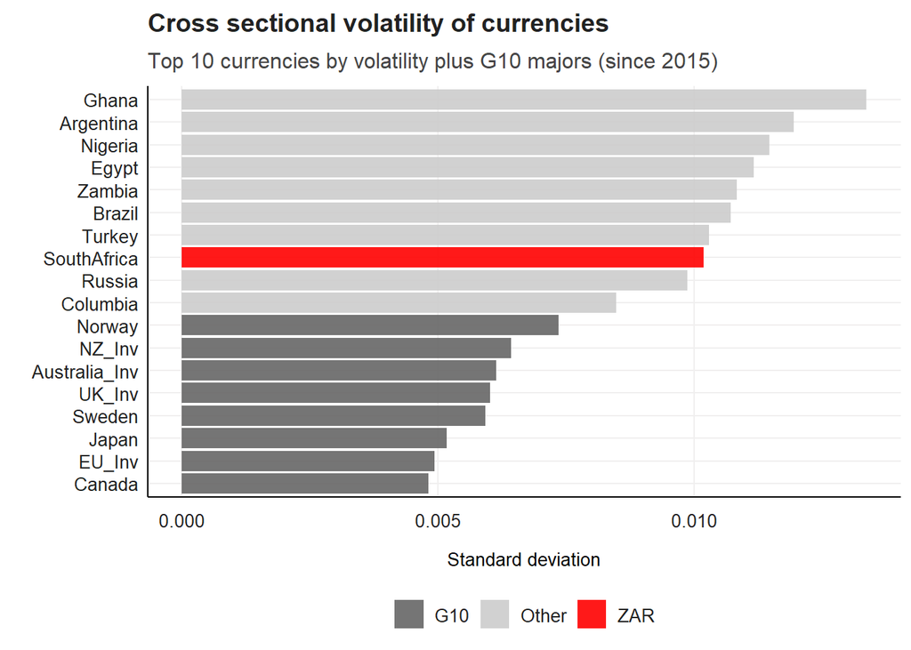

```r
# Create visualization to make the volatility comparison clear
# First, add ranks to our volatility data
vol_with_rank <- vol_cncy %>%
  arrange(desc(std_dev)) %>%
  mutate(rank = row_number())

# We want to show: top 10 most volatile currencies OR any G10 currency
# This ensures we see ZAR's position and how G10 currencies compare
plot_set <- vol_with_rank %>%
  filter(rank <= 10 | Group == "G10")

# Create the plot - using bars ordered by volatility
plot_set %>%
  mutate(Name = fct_reorder(Name, std_dev)) %>% # Order bars by volatility
  ggplot() +
  geom_col(aes(x = Name, y = std_dev, fill = Group), alpha = 0.9) +
  scale_fill_manual(
    values = c(
      "ZAR"   = "red",      # Highlight ZAR in red
      "G10"   = "grey40",   # G10 in dark grey
      "Other" = "grey80"    # Others in light grey
    )
  ) +
  coord_flip() + # Horizontal bars are easier to read with many categories
  labs(
    title    = "Cross sectional volatility of currencies",
    subtitle = "Top 10 currencies by volatility plus G10 majors (since 2015)",
    x = "",
    y = "Standard deviation",
    fill = ""
  ) +
  fmxdat::theme_fmx()
```

Again , SA is more volatile than the G10 currencies.

### 2. Analyzing ZAR return persistence

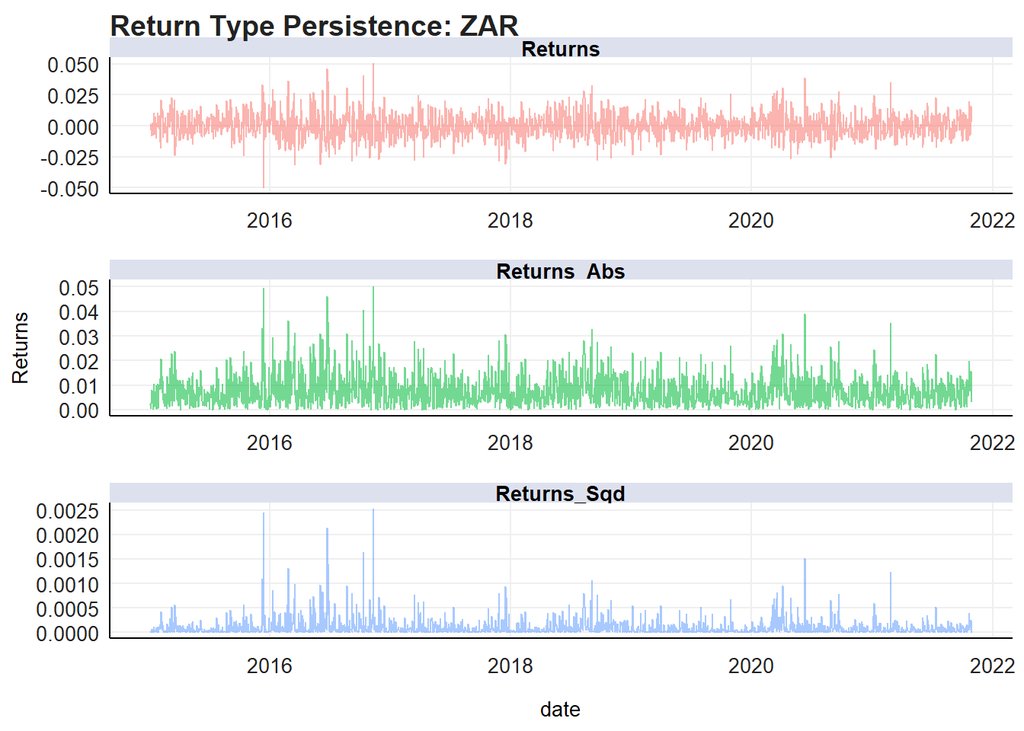

```r
# Now i focus specifically on ZAR for deeper analysis
# Using simple returns this time instead of log returns for GARCH modeling
zar_rts <- cncy %>%
  filter(date > ymd(20150101)) %>% # Consistent time period
  group_by(Name) %>%
  mutate(ret = Price / lag(Price) - 1) %>% # Simple return calculation
  filter(date > dplyr::first(date)) %>% # Remove NA
  ungroup() %>%
  mutate(Name = gsub("_Cncy", "", Name)) %>% # Clean names
  filter(Name == "SouthAfrica") %>% # Focus on ZAR only
  filter(!is.na(ret)) %>% # Remove any remaining NAs
  select(-Name, -Price) %>% # Keep only date and returns
  tbl_xts() # Convert to xts format for time series analysis

# I  Create three different return series to examine persistence (practical 6 ):
# Raw returns, squared returns (variance proxy), absolute returns (volatility proxy)
Plotdata <- cbind(zar_rts, zar_rts^2, abs(zar_rts))
colnames(Plotdata) <- c("Returns", "Returns_Sqd", "Returns_Abs")

# Convert back to tidy format for ggplot
Plotdata <- Plotdata %>%
  xts_tbl() %>%
  gather(ReturnType, Returns, -date)

# Plot to visually inspect persistence patterns
ggplot(Plotdata) +
  geom_line(aes(x = date, y = Returns, colour = ReturnType, alpha = 0.5)) +
  ggtitle("Return Type Persistence: ZAR") +
  facet_wrap(~ReturnType, nrow = 3, ncol = 1, scales = "free") + # Separate plots for each type
  guides(alpha = "none", colour = "none") + # Remove legends
  fmxdat::theme_fmx()
```

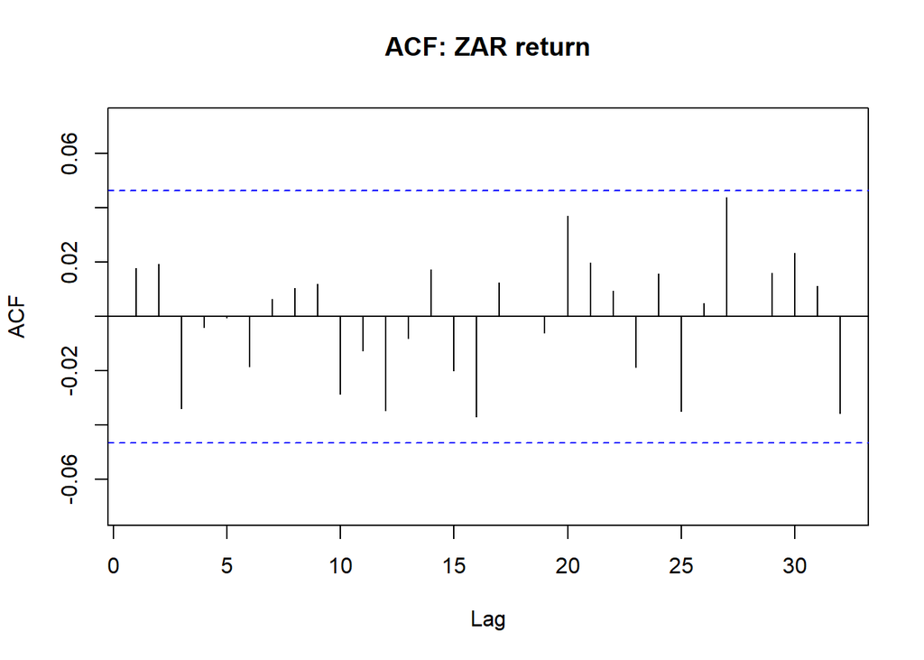

```r
# Autocorrelation analysis - prep for GARCH
# If returns show no autocorrelation but squared returns do, it suggests volatility clustering
forecast::Acf(zar_rts,   main = "ACF: ZAR return")           # Check raw return persistence
```

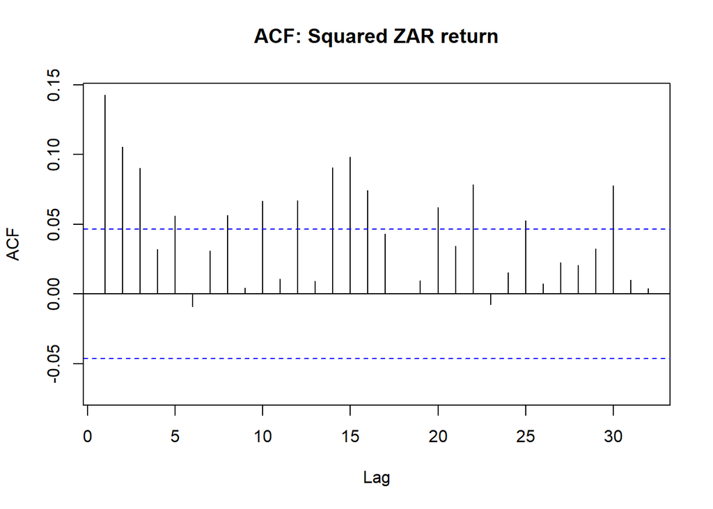

```r
forecast::Acf(zar_rts^2, main = "ACF: Squared ZAR return")   # Check volatility persistence
```

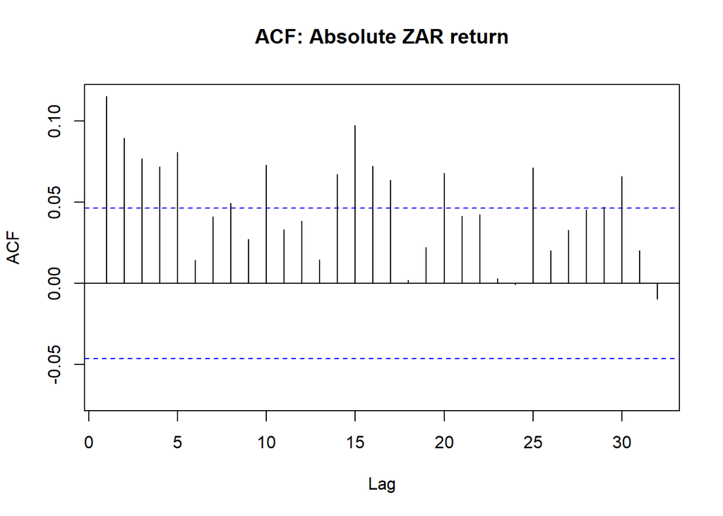

```r
forecast::Acf(abs(zar_rts), main = "ACF: Absolute ZAR return") # Alternative volatility measure
```

```r
# Formal test for ARCH effects - significant p-value means volatility clustering exists
Box.test(coredata(zar_rts^2), type = "Ljung-Box", lag = 12)
```

```
##
##  Box-Ljung test
##
## data:  coredata(zar_rts^2)
## X-squared = 101.98, df = 12, p-value = 2.22e-16
```

“X-squared = 101.98, df = 12, p-value = 2.22e-16.” The small p-value means we reject the null hypothesis (no autocorrelation) in the squared returns. This suggests the presence of volatility clustering, and using a GARCH model could help capture the time-varying risk.

### Fitting GARCH(1,1) to ZAR (rugarch, copy of Practical 6)

```r
# Following the practical example structure for consistency
porteqw <- zar_rts # Renaming to match practical example

# Specify GARCH(1,1) model - this took some time to get right
garch11 <- ugarchspec(
  variance.model = list(
    model      = c("sGARCH","gjrGARCH","eGARCH","fGARCH","apARCH")[1], # Standard GARCH
    garchOrder = c(1, 1) # 1 ARCH term, 1 GARCH term
  ),
  mean.model = list(
    armaOrder    = c(1, 0), # AR(1) model for mean
    include.mean = TRUE     # Include constant in mean equation
  ),
  distribution.model = c("norm", "snorm", "std", "sstd", "ged", "sged", "nig", "ghyp", "jsu")[1] # Normal distribution
)

# Fit the model - this can take a moment
garchfit1 <- ugarchfit(spec = garch11, data = porteqw)

# Display results
garchfit1
```

```
##
## *---------------------------------*
## *          GARCH Model Fit        *
## *---------------------------------*
##
## Conditional Variance Dynamics
## -----------------------------------
## GARCH Model  : sGARCH(1,1)
## Mean Model   : ARFIMA(1,0,0)
## Distribution : norm
##
## Optimal Parameters
## ------------------------------------
##         Estimate  Std. Error  t value Pr(>|t|)
## mu      0.000210    0.000228   0.9210 0.357051
## ar1     0.007943    0.024164   0.3287 0.742384
## omega   0.000002    0.000002   1.3423 0.179506
## alpha1  0.047048    0.013849   3.3972 0.000681
## beta1   0.932795    0.017406  53.5892 0.000000
##
## Robust Standard Errors:
##         Estimate  Std. Error  t value Pr(>|t|)
## mu      0.000210    0.000223  0.94112  0.34664
## ar1     0.007943    0.023268  0.34135  0.73284
## omega   0.000002    0.000009  0.22713  0.82033
## alpha1  0.047048    0.062538  0.75231  0.45186
## beta1   0.932795    0.089069 10.47277  0.00000
##
## LogLikelihood : 5680.695
##
## Information Criteria
## ------------------------------------
##
## Akaike       -6.3772
## Bayes        -6.3618
## Shibata      -6.3772
## Hannan-Quinn -6.3715
##
## Weighted Ljung-Box Test on Standardized Residuals
## ------------------------------------
```

[output cut: 40 more lines]

```
## Negative Sign Bias  0.6004 0.54835
## Positive Sign Bias  1.8345 0.06675   *
## Joint Effect        8.9794 0.02957  **
##
##
## Adjusted Pearson Goodness-of-Fit Test:
## ------------------------------------
##   group statistic p-value(g-1)
## 1    20     33.82       0.0193
## 2    30     35.84       0.1782
## 3    40     47.28       0.1704
## 4    50     56.46       0.2162
##
##
## Elapsed time : 0.2569571
```

```r
# Extract coefficient table
garch_tab <- garchfit1@fit$matcoef
kableExtra::kable(garch_tab, caption = "GARCH(1,1) estimates for ZAR")
```

GARCH(1,1) estimates for ZAR

|  | Estimate | Std. Error | t value | Pr(>\|t\|) |
| --- | --- | --- | --- | --- |
| mu | 0.0002100 | 0.0002280 | 0.9209990 | 0.3570509 |
| ar1 | 0.0079425 | 0.0241636 | 0.3286986 | 0.7423835 |
| omega | 0.0000021 | 0.0000016 | 1.3422773 | 0.1795061 |
| alpha1 | 0.0470482 | 0.0138493 | 3.3971619 | 0.0006809 |
| beta1 | 0.9327955 | 0.0174064 | 53.5892150 | 0.0000000 |

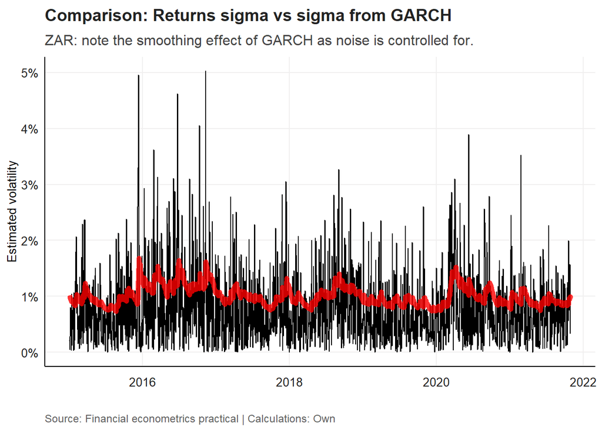

```r
# Plot the estimated conditional volatility from GARCH
sigma <- sigma(garchfit1) %>% xts_tbl() # Extract conditional sigma
colnames(sigma) <- c("date", "sigma")
sigma <- sigma %>% mutate(date = as.Date(date))

# Compare GARCH volatility with simple squared returns volatility
gg <- ggplot() +
  # Plot rolling volatility from squared returns (naive approach)
  geom_line(
    data = Plotdata %>%
      filter(ReturnType == "Returns_Sqd") %>%
      select(date, Returns) %>%
      unique() %>%
      mutate(Returns = sqrt(Returns)), # Convert variance to volatility
    aes(x = date, y = Returns)
  ) +
  # Overlay GARCH volatility in red
  geom_line(
    data = sigma,
    aes(x = date, y = sigma),
    color = "red", size = 2, alpha = 0.8
  ) +
  labs(
    title    = "Comparison: Returns sigma vs sigma from GARCH",
    subtitle = "ZAR: note the smoothing effect of GARCH as noise is controlled for.",
    x = "", y = "Estimated volatility",
    caption = "Source: Financial econometrics practical | Calculations: Own"
  ) +
  fmxdat::theme_fmx(CustomCaption = TRUE)
fmxdat::finplot(gg, y.pct = TRUE, y.pct_acc = 1)
```

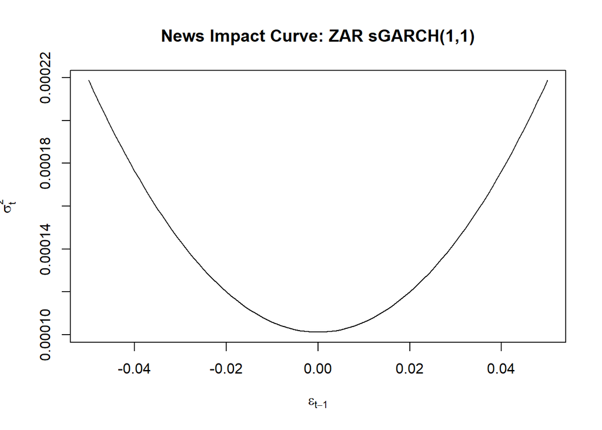

```r
# News Impact Curve - shows how news (shocks) affect future volatility
ni <- newsimpact(z = NULL, garchfit1)

# Plot the NIC - I struggled to understand this at first
# It shows asymmetry: how positive vs negative shocks impact volatility differently
plot(
  ni$zx, ni$zy,
  ylab = ni$yexpr,
  xlab = ni$xexpr,
  type = "l",
  main = "News Impact Curve: ZAR sGARCH(1,1)"
)
```

### Alternative GARCH forms for ZAR (GJR and EGARCH) and NIC comparison

```r
# Standard GARCH assumes symmetric volatility response
# But in finance, negative shocks often increase volatility more (leverage effect)
# So i try asymmetric GARCH models

# GJR-GARCH with student t distribution - accounts for leverage effect
gjrgarch11 <- ugarchspec(
  variance.model = list(
    model      = c("sGARCH","gjrGARCH","eGARCH","fGARCH","apARCH")[2], # GJR-GARCH
    garchOrder = c(1, 1)
  ),
  mean.model = list(
    armaOrder    = c(1, 0),
    include.mean = TRUE
  ),
  distribution.model = c("norm", "snorm", "std", "sstd", "ged", "sged", "nig", "ghyp", "jsu")[3] # Student t
)

garchfit2 <- ugarchfit(spec = gjrgarch11, data = as.matrix(porteqw))

# Display results
kableExtra::kable(
  garchfit2@fit$matcoef,
  caption = "GJR GARCH(1,1) with student t distribution for ZAR"
)
```

GJR GARCH(1,1) with student t distribution for ZAR

|  | Estimate | Std. Error | t value | Pr(>\|t\|) |
| --- | --- | --- | --- | --- |
| mu | 0.0001830 | 0.0002287 | 0.8004381 | 0.4234570 |
| ar1 | 0.0015262 | 0.0239441 | 0.0637397 | 0.9491775 |
| omega | 0.0000012 | 0.0000007 | 1.7036342 | 0.0884494 |
| alpha1 | 0.0473653 | 0.0071176 | 6.6547069 | 0.0000000 |
| beta1 | 0.9645691 | 0.0038471 | 250.7238625 | 0.0000000 |
| gamma1 | -0.0502927 | 0.0112761 | -4.4601190 | 0.0000082 |
| shape | 14.0711878 | 4.0824995 | 3.4467090 | 0.0005675 |

```r
# EGARCH - another asymmetric model with exponential form
egarch11 <- ugarchspec(
  variance.model = list(
    model      = c("sGARCH","gjrGARCH","eGARCH","fGARCH","apARCH")[3], # EGARCH
    garchOrder = c(1, 1)
  ),
  mean.model = list(
    armaOrder    = c(1, 0),
    include.mean = TRUE
  ),
  distribution.model = c("norm", "snorm", "std", "sstd", "ged", "sged", "nig", "ghyp", "jsu")[3] # Student t
)

garchfit3 <- ugarchfit(spec = egarch11, data = as.matrix(porteqw))

# Model diagnostics and comparison
signbias(garchfit1) # Test for sign bias - if significant, asymmetric models are better
```

```
##                      t-value       prob sig
## Sign Bias          0.1116684 0.91109896
## Negative Sign Bias 0.6003544 0.54834668
## Positive Sign Bias 1.8344545 0.06675385   *
## Joint Effect       8.9793762 0.02956635  **
```

```r
infocriteria(garchfit1) # Information criteria for model selection
```

```
##
## Akaike       -6.377186
## Bayes        -6.361780
## Shibata      -6.377202
## Hannan-Quinn -6.371496
```

```r
infocriteria(garchfit2)
```

```
##
## Akaike       -6.391203
## Bayes        -6.369635
## Shibata      -6.391233
## Hannan-Quinn -6.383237
```

```r
infocriteria(garchfit3)
```

```
##
## Akaike       -6.387688
## Bayes        -6.366120
## Shibata      -6.387718
## Hannan-Quinn -6.379722
```

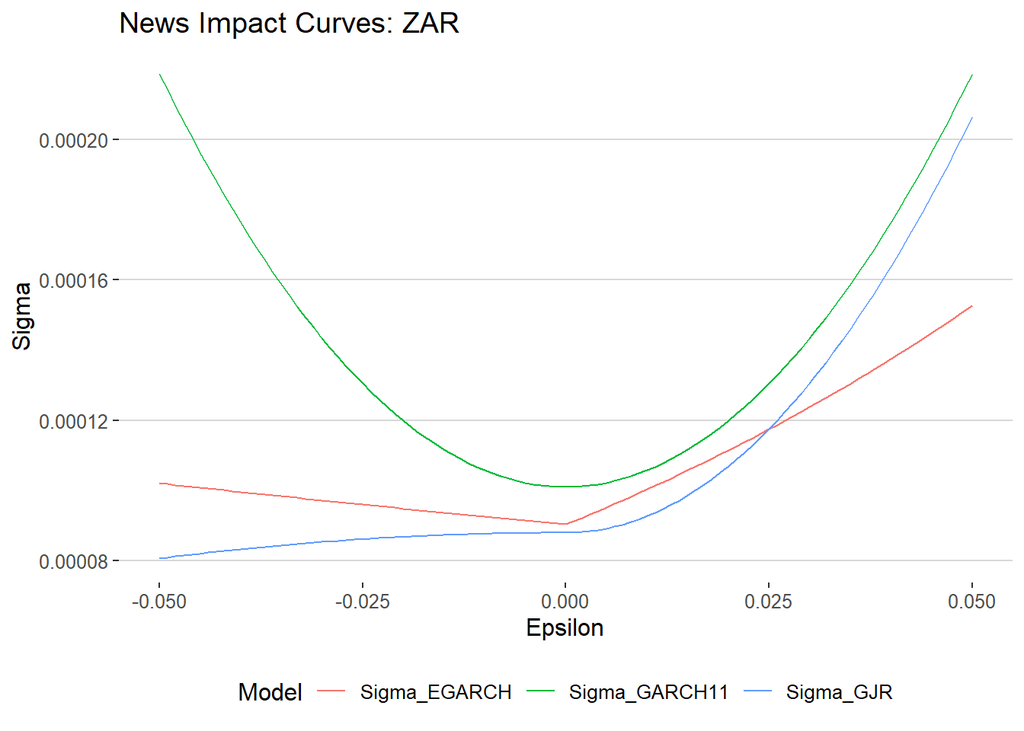

```r
# Compare News Impact Curves across all three models
#function to extract NIC data - copied from practical
NICurveMaker <- function(Fit, Name) {
  NI <- newsimpact(z = NULL, Fit)
  NI <- cbind(NI$zx, NI$zy)
  colnames(NI) <- c(paste0("Epsilon_", Name), paste0("Sigma_", Name))
  NI %>% data.frame() %>% tibble::as_tibble()
}

# Extract NIC data for all three models
NI1 <- NICurveMaker(garchfit1, "GARCH11")
NI2 <- NICurveMaker(garchfit2, "GJR")
NI3 <- NICurveMaker(garchfit3, "EGARCH")

# Combine and reshape for plotting
NI <- cbind(NI1, NI2, NI3) %>%
  gather(Model, Sigma, starts_with("Sigma")) %>%
  rename(Epsilon = Epsilon_GARCH11) %>%
  select(-Epsilon_GJR, -Epsilon_EGARCH)

# Plot comparison - this clearly shows asymmetry differences
ggplot(NI) +
  geom_line(aes(x = Epsilon, y = Sigma, colour = Model)) +
  ggtitle("News Impact Curves: ZAR") +
  theme_hc()
```

### GO GARCH and time varying correlation between ZAR and Dollar strength

```r
# Now  i  examine the second statement about Dollar strength using prac 7 - multivariate analysis
#I analyse the  correlation between ZAR and Dollar index

# Calculate Dollar index log returns
g10_rts <- bbdxy %>%
  arrange(date) %>%
  mutate(G10 = log(Price) - log(lag(Price))) %>% # Log returns for Dollar index
  filter(date > dplyr::first(date)) %>%
  select(date, G10)

# Get ZAR log returns from our earlier calculation
zar_log_rts <- cncy_rts %>%
  filter(Name == "SouthAfrica") %>%
  rename(ZAR = dlogret) %>%
  select(date, ZAR)

# Merge and convert to xts for multivariate GARCH
xts_rtn <- left_join(g10_rts, zar_log_rts, by = "date") %>%
  drop_na() %>% # Remove any missing values
  tbl_xts() # Convert to xts format
```

```r
# function from practical to rename DCC correlation outputs
# This was complex - had to carefully study how the correlation matrices are structured ( struggled a bit )
renamingdcc <- function(ReturnSeries, DCC.TV.Cor) {
  dates <- zoo::index(ReturnSeries)
  N     <- ncol(ReturnSeries)
  names <- colnames(ReturnSeries)

  # Create all possible pairs
  pairs      <- expand.grid(names, names)
  pair_names <- paste0(pairs$Var1, "_", pairs$Var2)

  df <- as.data.frame(DCC.TV.Cor)
  colnames(df) <- pair_names
  df$date      <- dates

  # Reshape to long format for plotting
  df %>%
    tidyr::pivot_longer(
      cols      = -date,
      names_to  = "Pairs",
      values_to = "Rho"
    ) %>%
    dplyr::arrange(date)
}
```

```r
# GO-GARCH model for multivariate volatility
# This allows us to estimate time-varying correlation

# First specify univariate GARCH models for each series
uspec <- ugarchspec(
  variance.model = list(
    model      = "gjrGARCH", # Using GJR-GARCH for asymmetry
    garchOrder = c(1, 1)
  ),
  mean.model = list(
    armaOrder    = c(1, 0),
    include.mean = TRUE
  ),
  distribution.model = "sstd" # Skewed student t for fat tails and asymmetry
)

# Replicate specification for both series
multi_univ_garch_spec <- multispec(replicate(ncol(xts_rtn), uspec))

# GO-GARCH specification
spec.go <- gogarchspec(
  multi_univ_garch_spec,
  distribution.model = "mvnorm", # Multivariate normal
  ica                = "fastica" # Independent component analysis
)

# Use parallel processing - this speeds up estimation significantly
cl <- makePSOCKcluster(10)

# Fit univariate models first
multf <- multifit(multi_univ_garch_spec, xts_rtn, cluster = cl)

# Fit GO-GARCH model - this can take a while
fit.gogarch <- gogarchfit(
  spec    = spec.go,
  data    = xts_rtn,
  solver  = "hybrid",
  cluster = cl,
  gfun    = "tanh",
  maxiter1 = 40000,
  epsilon  = 1e-08,
  rseed    = 100
)

stopCluster(cl) # Always stop cluster when done

print(fit.gogarch)
```

```
##
## *------------------------------*
## *        GO-GARCH Fit          *
## *------------------------------*
##
## Mean Model       : CONSTANT
## GARCH Model      : sGARCH
## Distribution : mvnorm
## ICA Method       : fastica
## No. Factors      : 2
## No. Periods      : 4390
## Log-Likelihood   : 33146.13
## ------------------------------------
##
## U (rotation matrix) :
##
##       [,1]   [,2]
## [1,] 0.746  0.666
## [2,] 0.666 -0.746
##
## A (mixing matrix) :
##
##           [,1]    [,2]
## [1,] -0.000363 0.00406
## [2,]  0.008454 0.00655
```

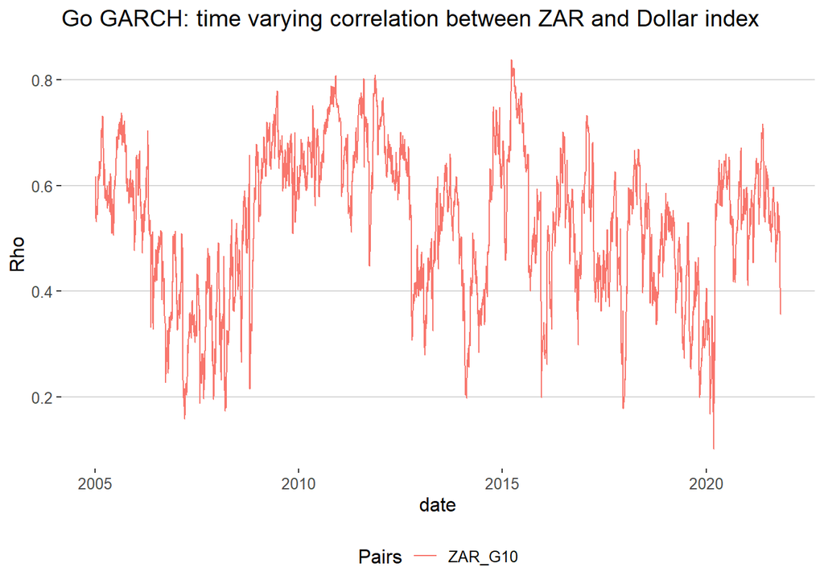

```r
# Extract time-varying correlations
gog.time.var.cor <- rcor(fit.gogarch)
gog.time.var.cor <- aperm(gog.time.var.cor, c(3, 2, 1)) # Rearrange dimensions
dim(gog.time.var.cor) <- c(
  nrow(gog.time.var.cor),
  ncol(gog.time.var.cor)^2
)

# Use renamingdcc function to rename and reshape
gog.time.var.cor <- renamingdcc(
  ReturnSeries = xts_rtn,
  DCC.TV.Cor   = gog.time.var.cor
)

# Plot the time-varying correlation between ZAR and Dollar index
g2 <- ggplot(
  gog.time.var.cor %>%
    filter(grepl("ZAR_", Pairs), !grepl("_ZAR", Pairs)) # Get ZAR pairs but not ZAR_ZAR
) +
  geom_line(aes(x = date, y = Rho, colour = Pairs)) +
  theme_hc() +
  ggtitle("Go GARCH: time varying correlation between ZAR and Dollar index")

print(g2)
```

### G10 carry and PPP value (for narrative)

I added this but was unsure about it

```r
# Finally, let's examine the relationships mentioned in the second statement
# Calculate returns for all relevant series

# ZAR returns (already calculated)
zar_daily <- cncy_rts %>% filter(Name == "SouthAfrica") %>% select(date, ZAR = dlogret)

# G10 carry index returns
carry_rts <- cncy_Carry %>%
  arrange(date) %>%
  mutate(Carry = log(Price) - log(lag(Price))) %>%
  filter(!is.na(Carry)) %>%
  select(date, Carry)

# PPP value index returns
value_rts <- cncy_value %>%
  arrange(date) %>%
  mutate(Value = log(Price) - log(lag(Price))) %>%
  filter(!is.na(Value)) %>%
  select(date, Value)

# Dollar index returns (alternative calculation)
dxy_rts <- bbdxy %>%
  arrange(date) %>%
  mutate(DXY = log(Price) - log(lag(Price))) %>%
  filter(!is.na(DXY)) %>%
  select(date, DXY)

# Combine all series
link_df <- zar_daily %>%
  inner_join(carry_rts, by = "date") %>%
  inner_join(value_rts, by = "date") %>%
  inner_join(dxy_rts,   by = "date")

# Calculate correlation matrix - this gives us the relationships
round(cor(link_df %>% select(-date), use = "complete.obs"), 3)
```

```
##          ZAR  Carry  Value    DXY
## ZAR    1.000 -0.326  0.246  0.539
## Carry -0.326  1.000 -0.142 -0.202
## Value  0.246 -0.142  1.000  0.322
## DXY    0.539 -0.202  0.322  1.000
```

ZAR ranks as the 8th most volatile currency among 41 currencies in the sample (starting year = 2015 , if we change it to 2016/2017 it moves up to number 5), and is more volatile than all G10 currencies. Univariate GARCH models confirm strong and persistent volatility clustering for ZAR. The asymmetric GJR GARCH model further suggests that positive shocks to ZAR returns increase volatility more than negative shocks of the same magnitude.

ZAR shows moderate relationships with carry and value factors, with correlations of about −0.33 with the G10 carry index and +0.25 with the value index. However, the claim that ZAR benefits from periods of strong Dollar performance is not supported by the data. ZAR returns are positively correlated with the Dollar index (about +0.54), which in this quotation convention means that ZAR typically weakens when the Dollar strengthens. GO GARCH results indicate that this relationship is time varying, so in this sample the statement is not strongly supported.

The GJR GARCH model indicates that ZAR volatility responds more strongly to positive shocks than to negative shocks (γ ≈ −0.05), which is the opposite of the usual leverage effect found in equity markets. This points to a different volatility mechanism for ZAR, consistent with the idea that good news rallies and periods of strong inflows can be associated with elevated and persistent volatility in an emerging market currency.